# projet_Practical_Machine_Learning

Raquel Martín de Consuegra

12 de marzo de 2016

# Loading libraries

Load library if you have a problem maybe need install packages

```r
library(lattice)
library(caret)
library(randomForest)
```

```r
library(rpart)
library(rpart.plot)
library(e1071)
```

# Loading data

Load data by web also you can use data from computer for this you need change de url

```r
trainingSet <- read.csv("http://d396qusza40orc.cloudfront.net/predmachlearn/pml-training.csv", sep=",", na.strings=c("NA","#DIV/0!",""))
testingSet <- read.csv('http://d396qusza40orc.cloudfront.net/predmachlearn/pml-testing.csv', sep=",", na.strings=c("NA","#DIV/0!",""))
```

# Preprocessing the data

We delete columns whose data is not important for prediction. these are: X, user_name, raw_timestamp_part_1, raw_timestamp_part_2, cvtd_timestamp, new_window, num_window

```r
trainingSet <-trainingSet[,-c(1:7)]
testingSet <-testingSet[,-c(1:7)]
```

With this assign “# DIV / 0!” And “” to the NA

```r
trainingSet[trainingSet == "#DIV/0!"] <- NA
trainingSet[trainingSet == ""] <- NA
```

Find the columns whose values represent more than NA 75 %.

```r
highNAs <- sapply(trainingSet, function(x){mean(is.na(x))>0.75})
```

We get rid of these columns

```r
trainingSet <- trainingSet[,highNAs == FALSE]
testingSet <- testingSet[,highNAs == FALSE]
```

If you want have a same result, need put this seed

```r
set.seed(1986)
```

# Cross-validation

For my cross-validation I created two parts. One with 70% of the data and the other 30% of data

```r
traintrainSet <- createDataPartition(y=trainingSet$classe, p=0.7, list=FALSE)
TrainTrainingSet <- trainingSet[traintrainSet, ]
TestTrainingSet <- trainingSet[-traintrainSet, ]
```

classe has 5 levels : A, B , C , D and E. A plot shows the frequency of variables

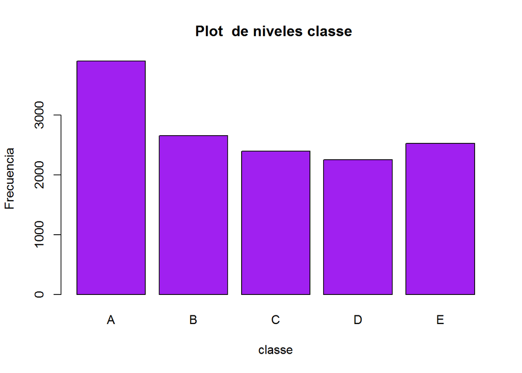

```r
plot(TrainTrainingSet$classe, col="purple", main="Plot  de niveles classe ", xlab="classe", ylab="Frecuencia")
```

# Building a model

I compared two models to choose from that have a greater accuracy

## Moldel 1: rpart

rpart make only one tree decision. Now make the model

```r
model1 <- rpart(classe ~ ., data=TrainTrainingSet, method="class")
```

and predict

```r
prediction1 <- predict(model1, TestTrainingSet, type = "class")

# Result Model 1:
confusionMatrix(prediction1, TestTrainingSet$classe)
```

```
## Confusion Matrix and Statistics
##
##           Reference
## Prediction    A    B    C    D    E
##          A 1497  230   19  120   34
##          B   47  578  112   33   67
##          C   38  147  781   77   83
##          D   62   78   74  659   96
##          E   30  106   40   75  802
##
## Overall Statistics
##
##                Accuracy : 0.7336
##                  95% CI : (0.7221, 0.7448)
##     No Information Rate : 0.2845
##     P-Value [Acc > NIR] : < 2.2e-16
##
##                   Kappa : 0.6616
##  Mcnemar's Test P-Value : < 2.2e-16
##
## Statistics by Class:
##
##                      Class: A Class: B Class: C Class: D Class: E
## Sensitivity            0.8943  0.50746   0.7612   0.6836   0.7412
## Specificity            0.9043  0.94543   0.9290   0.9370   0.9477
## Pos Pred Value         0.7879  0.69056   0.6936   0.6801   0.7616
## Neg Pred Value         0.9556  0.88887   0.9485   0.9380   0.9421
## Prevalence             0.2845  0.19354   0.1743   0.1638   0.1839
## Detection Rate         0.2544  0.09822   0.1327   0.1120   0.1363
## Detection Prevalence   0.3229  0.14223   0.1913   0.1647   0.1789
## Balanced Accuracy      0.8993  0.72645   0.8451   0.8103   0.8445
```

## Moldel 2: random Forest

Random Forest works by making many decision trees on different subsets of the regressors and averaging them together

```r
model <- randomForest(classe ~. , data=TrainTrainingSet, method="class")
```

and predict

```r
prediction <- predict(model, TestTrainingSet, type = "class")
confusionMatrix(prediction, TestTrainingSet$classe)
```

```
## Confusion Matrix and Statistics
##
##           Reference
## Prediction    A    B    C    D    E
##          A 1671    3    0    0    0
##          B    2 1130    4    0    0
##          C    0    6 1022    6    0
##          D    0    0    0  956    2
##          E    1    0    0    2 1080
##
## Overall Statistics
##
##                Accuracy : 0.9956
##                  95% CI : (0.9935, 0.9971)
##     No Information Rate : 0.2845
##     P-Value [Acc > NIR] : < 2.2e-16
##
##                   Kappa : 0.9944
##  Mcnemar's Test P-Value : NA
##
## Statistics by Class:
##
##                      Class: A Class: B Class: C Class: D Class: E
## Sensitivity            0.9982   0.9921   0.9961   0.9917   0.9982
## Specificity            0.9993   0.9987   0.9975   0.9996   0.9994
## Pos Pred Value         0.9982   0.9947   0.9884   0.9979   0.9972
## Neg Pred Value         0.9993   0.9981   0.9992   0.9984   0.9996
## Prevalence             0.2845   0.1935   0.1743   0.1638   0.1839
## Detection Rate         0.2839   0.1920   0.1737   0.1624   0.1835
## Detection Prevalence   0.2845   0.1930   0.1757   0.1628   0.1840
## Balanced Accuracy      0.9987   0.9954   0.9968   0.9956   0.9988
```

## Choice of model

Random forest is an ensemble learning method used for classification and regression. It uses multiple models for better performance that just using a single tree model as rpart. For this and because accuracy’s Random forest is better than rpart I choose Random forest.

# Predictions for results

Now let’s try data testingSet

```r
predicionfinal <- predict(model, testingSet, type="class")
predicionfinal
```

```
##  1  2  3  4  5  6  7  8  9 10 11 12 13 14 15 16 17 18 19 20
##  B  A  B  A  A  E  D  B  A  A  B  C  B  A  E  E  A  B  B  B
## Levels: A B C D E
```

# Conclusions

There are many prediction models so that they are more accurately ajunste it’s necessary to make a proper cleaning of the data. It is also very important cross-validation to check preccision model.